# PAC2 Análisis Datos Omicos

Raúl Pérez Prats

2024-05-23

# Tabla de contenidos

## 1. Introducción

## 2. Objetivos

## 3. Métodos

## 4. Resultados

## 5. Apéndices

## Introducción

La leucemia mieloblástica es un tipo de cáncer que afecta a las células mieloides en la médula ósea, las cuales son responsables de la producción de glóbulos blancos, glóbulos rojos y plaquetas. Esta enfermedad se caracteriza por la proliferación incontrolada de células inmaduras llamadas blastos mieloides, que interfieren con la producción normal de células sanguíneas y se acumulan en la médula ósea y en la sangre periférica.

La leucemia mieloblástica se divide principalmente en leucemia mieloide aguda (LMA) y leucemia mieloide crónica (LMC) en función de la rapidez con la que la enfermedad progresa y las características clínicas y genéticas específicas.

La leucemia mieloide aguda (LMA) es una forma agresiva de leucemia que progresa rápidamente. Se caracteriza por un aumento rápido y descontrolado de blastos mieloides inmaduros en la médula ósea y en la sangre.

La leucemia mieloide crónica (LMC) es una forma más lenta y progresiva de leucemia que se caracteriza por el aumento de glóbulos blancos maduros y parcialmente maduros en la médula ósea y en la sangre.

## Objetivos

### Objetivos Principales

En esta PEC se caracterizará la leucemia mieloblastica a través de la expresión génica mediante las comparaciones:

- Leucemia mieloide aguda (AML) frente a leucemia mieloide crónica (CML)
- Leucemia mieloide aguda (AML) frente a “No leucemia” (NoL)
- Leucemia mieloide crónica (CML) frente a “No leucemia” (NoL)

### Objetivos secundários

- Preparar los datos
- Hacer un análisis exploratorio y control de calidad
- Construir las matrizes de diseño y de contrastes
- Obtener las listas de genes diferencialmente expresados para cada comparación
- Anotar los genes
- Analizar la significación biológica de las 3 comparaciones principales

## Métodos

Para realizar el análisis de expresión génica definido en los objetivos he descargado mediante Bioconductor el paquete “leukemiasEset”. A partir de este dataset he subseteado las muestras de los tipos AML, CML y NoL eliminando aleatoriamente dos muestras de cada grupo, estableciendo un set.seed = 1651919 para permitir la reproducibilidad.

Posteriormente he realizado un análisis exploratorio y de control de calidad mediante histogramas y boxplots para ver la distribución de la expresión génica en los grupos AML, CML y NoL, y he generado un report de calidad mediante el paquete arrayqualitymetrics. También he realizado un análisis con MA plots de los 3 grupos para observar la presencia de sesgos o ruído en los datos de los microarrays. Tras realizar las evaluaciones pertinentes he normalizado las muestras mediante una normalización global Log2.

He proseguido con la construcción de lasmatrices de diseño y de contrastes con el paquete ‘limma’ para poder obtener las listas de los genes diferenciamente expresados en las 3 comparaciones establecidas en los objetivos. También he realizado volcanoplots y venn diagrams para la visualización y la mejor comprensión de las listas de genes diferencialmente expresados.

A partir de estas listas he anotado los genes con el identificador Symbol.

Finalmente utilizando el paquete ‘clusterProfiler’ he realizado un Gene Set Enrichment Analysis (GSEA) y un KEGG pathway GSEA para visualizar los grupos de genes y las rutas metabólicas diferenciamente expresadas en los 3 grupos. Con esta información he descrito un análisis de la significación biológica.

## Resultados y Discusión

### Preparación de los datos

```r
library(leukemiasEset)
data("leukemiasEset") #Cargamos el dataset

# Metadata de las muestras
sample_metadata <- pData(leukemiasEset)
#sample_metadata
# seleccionamos los tipos 'AML', 'CML' y 'NoL'
selected_samples <- leukemiasEset[, sample_metadata[['LeukemiaType']] %in% c("AML", "CML", "NoL")]

#head(exprs(selected_samples))
#pData(selected_samples)
```

Elimino aleatoriamente dos mustras de cada clase de leucemia:

```r
set.seed(1651919) #fecha de nacimiento del Dr. Margalef


# Identificamos la columna del tipo de leucemia
leukemia_column <- "LeukemiaType"

# Creamos una lista para almacenar índices de muestras a conservar
indices_to_keep <- integer(0)

# Creamos una lista para almacenar los ID de las muestras que se eliminan
removed_sample_ids <- list()
# Procesamos cada tipo de leucemia
leukemia_types <- c("AML", "CML", "NoL")
for (type in leukemia_types) {
    # Indices de las muestras del tipo seleccionado
    type_indices <- which(selected_samples[[leukemia_column]] == type)

    # Sampleamos 2 indices a eliminar
    indices_to_remove <- sample(type_indices, 2)

    # Guardamos los indices a eliminar
    removed_sample_ids[[type]] <- rownames(pData(selected_samples))[indices_to_remove]
}
# vectorizamos las samples a eliminar
samples_to_remove <- unname(unlist(removed_sample_ids))


#Eliminamos las muestras seleccionadas aleatoriamente
selected_samples_r <- selected_samples[, !colnames(selected_samples) %in% samples_to_remove]

#Printamos expressionset
#exprs(selected_samples_r)

# Printamos head metadata
head(pData(selected_samples_r))
```

```
##               Project     Tissue LeukemiaType       LeukemiaTypeFullName
## GSM330532.CEL   Mile1 BoneMarrow          AML Acute Myelogenous Leukemia
## GSM330559.CEL   Mile1 BoneMarrow          AML Acute Myelogenous Leukemia
## GSM330566.CEL   Mile1 BoneMarrow          AML Acute Myelogenous Leukemia
## GSM330571.CEL   Mile1 BoneMarrow          AML Acute Myelogenous Leukemia
## GSM330580.CEL   Mile1 BoneMarrow          AML Acute Myelogenous Leukemia
## GSM330584.CEL   Mile1 BoneMarrow          AML Acute Myelogenous Leukemia
##                                                         Subtype
## GSM330532.CEL AML with normal karyotype and other abnormalities
## GSM330559.CEL AML with normal karyotype and other abnormalities
## GSM330566.CEL AML with normal karyotype and other abnormalities
## GSM330571.CEL AML with normal karyotype and other abnormalities
## GSM330580.CEL AML with normal karyotype and other abnormalities
## GSM330584.CEL AML with normal karyotype and other abnormalities
```

Este es el metadata del dataset final con el que trabajaré

### Análisis exploratorio y control de calidad

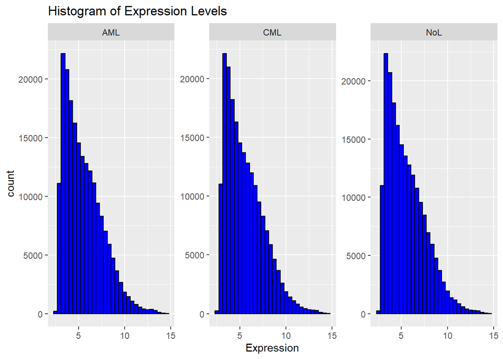

Los histogramas nos permiten observar los niveles de expresión más frecuentes en cada grupo de Leucemia. A simple vista no se pueden apreciar grandes diferencias entre los tres grupos, por lo tanto deberemos hacer un análisis más profundo para determinar si existen diferencias en los niveles de expresión de los genes de los diferentes grupos y si éstas son significativas.

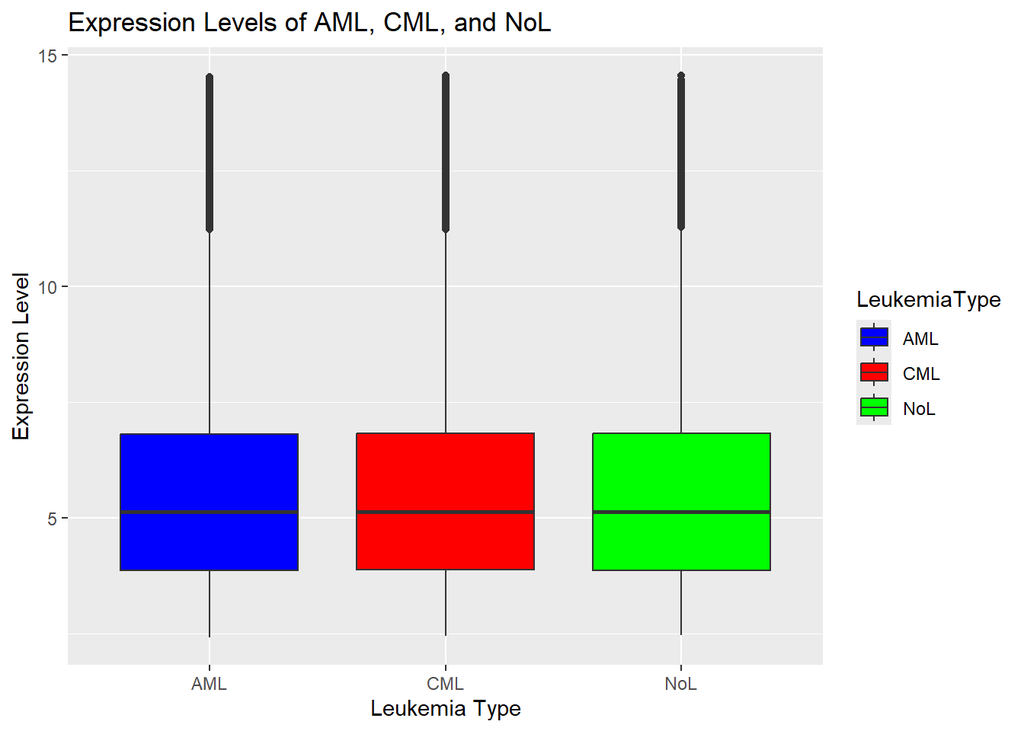

Los boxplots nos muestran más claramente que estos 3 grupos son muy similares a simple vista, debido a que tienen un valor promedio de expresión de los genes muy parecido, y además presentan una cola de outliers en la parte superior de la distribución.

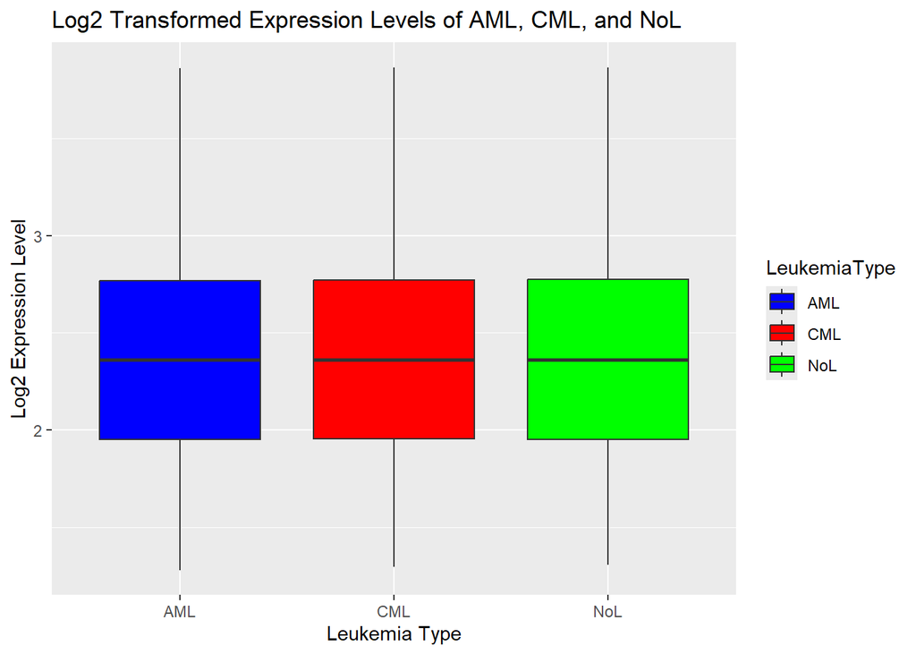

Intentamos corregir la asimetría mencionada anteriormente realizando una transformación logarítmica del ExpressionSet. La transformación ha resultado en una distribución de los niveles de expresión más simétrica en los 3 grupos.

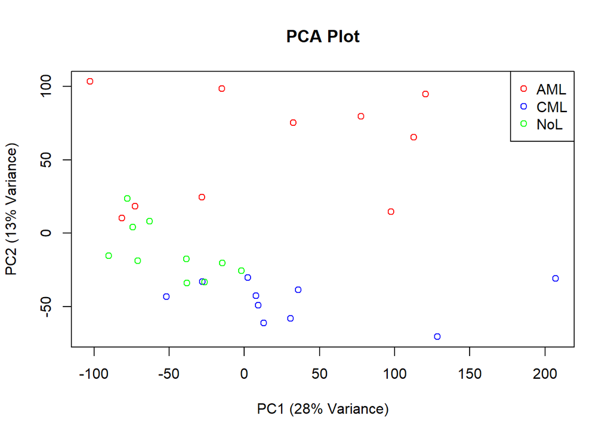

El PCA, pese a expresar un 41% de la variancia total, muestra como se distribuyen y separan nuestras muestras de los 3 grupos. Se observa como cada grupo permanece parcialmente agrupado y es diferenciable de los demás grupos, ya que encontramos a las muestras de AML en la parte superior del gráfico, CML en la parte inferior y NoL en la parte central, muy cerca de los puntos de AML y CML. El PCA muestra como los grupos AML y CML quedan muy claramente diferenciados, ya que estan en posiciones opuestas respecto al eje vertical, mientras que NoL queda entre los dos grupos sin estar tan claramente diferenciado.

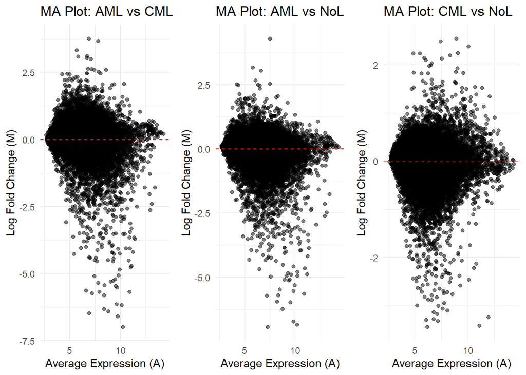

[figure not shown]

En la primera imagen están representados los MA plots de las 3 posibles comparaciones. Se puede apreciar como la distribución de LogFoldChange respecto al promedio de expresión es bastante asimétrica en los 3 casos, principalmente debido a los outliers que presentan por debajo de la linea horizontal de LogFoldChange = 0.

Cuando repetimos el análisis con los datos tratados mediante una normalización global Log2 vemos que los MA plots se vuelven más simétricos debido a la reducción de outliers, tal y como habíamos visto también en el boxplot.

Usaremos los datos tratados con esta transformación para el análisis debido a que, al hacer nuestros datos más simétricos en el boxplot y en el MA plot, corrige parte del ruido de nuestra muestra y parte de los posibles sesgos técnicos.

### Construcción de las matrices de diseño y de contrastes

Matriz de diseño

```r
library(limma)

sample_info$LeukemiaType <- factor(sample_info$LeukemiaType, levels = c("AML", "CML", "NoL"))
design_matrix <- model.matrix(~ 0 + LeukemiaType, data = sample_info)
colnames(design_matrix) <- levels(sample_info$LeukemiaType)

print('MATRIZ DE DISEÑO')
```

```
## [1] "MATRIZ DE DISEÑO"
```

```r
print(design_matrix)
```

```
##               AML CML NoL
## GSM330532.CEL   1   0   0
## GSM330559.CEL   1   0   0
## GSM330566.CEL   1   0   0
## GSM330571.CEL   1   0   0
## GSM330580.CEL   1   0   0
## GSM330584.CEL   1   0   0
## GSM330593.CEL   1   0   0
## GSM330603.CEL   1   0   0
## GSM330611.CEL   1   0   0
## GSM330612.CEL   1   0   0
## GSM331377.CEL   0   1   0
## GSM331378.CEL   0   1   0
## GSM331381.CEL   0   1   0
## GSM331382.CEL   0   1   0
## GSM331386.CEL   0   1   0
## GSM331387.CEL   0   1   0
## GSM331389.CEL   0   1   0
## GSM331390.CEL   0   1   0
## GSM331392.CEL   0   1   0
## GSM331393.CEL   0   1   0
## GSM331660.CEL   0   0   1
## GSM331661.CEL   0   0   1
## GSM331663.CEL   0   0   1
## GSM331666.CEL   0   0   1
## GSM331671.CEL   0   0   1
## GSM331672.CEL   0   0   1
## GSM331673.CEL   0   0   1
## GSM331674.CEL   0   0   1
## GSM331675.CEL   0   0   1
## GSM331677.CEL   0   0   1
## attr(,"assign")
## [1] 1 1 1
## attr(,"contrasts")
## attr(,"contrasts")$LeukemiaType
## [1] "contr.treatment"
```

```r
contrast_matrix <- makeContrasts(
  AMLvsCML = AML - CML,
  AMLvsNoL = AML - NoL,
  CMLvsNoL = CML - NoL,
  levels = design_matrix
)
print(contrast_matrix)
```

```
##       Contrasts
## Levels AMLvsCML AMLvsNoL CMLvsNoL
##    AML        1        1        0
##    CML       -1        0        1
##    NoL        0       -1       -1
```

### Obtención de las listas de genes diferencialmente expresados para cada comparación

```
## [1] "Head genes diferencialmente expresados en AMLvsCML"
```

```
##                      logFC  AveExpr         t      P.Value    adj.P.Val
## ENSG00000160180 -0.9394757 2.831421 -16.20250 9.958862e-17 2.008902e-12
## ENSG00000229314 -1.2056007 2.917226 -15.55192 3.114904e-16 3.141692e-12
## ENSG00000100985 -0.9252176 3.393188 -15.25085 5.347150e-16 3.305591e-12
## ENSG00000133048 -1.1715602 3.121533 -15.06964 7.431952e-16 3.305591e-12
## ENSG00000184292 -0.9413577 2.854048 -15.01626 8.193514e-16 3.305591e-12
## ENSG00000196576  0.6223918 2.816609  14.06150 4.912516e-15 1.498235e-11
##                        B
## ENSG00000160180 27.37218
## ENSG00000229314 26.35046
## ENSG00000100985 25.86311
## ENSG00000133048 25.56522
## ENSG00000184292 25.47682
## ENSG00000196576 23.84296
```

```
## [1] "HeadTop 5 genes diferencialmente expresados en AMLvsNoL"
```

```
##                      logFC  AveExpr         t      P.Value    adj.P.Val
## ENSG00000229314 -1.2204634 2.917226 -15.74364 2.217351e-16 4.472840e-12
## ENSG00000102837 -1.5440138 2.846121 -15.03392 7.933036e-16 8.001260e-12
## ENSG00000133063 -1.0943842 2.722479 -14.68137 1.520351e-15 8.845950e-12
## ENSG00000133048 -1.1263642 3.121533 -14.48829 2.181974e-15 8.845950e-12
## ENSG00000184292 -0.9080971 2.854048 -14.48570 2.192631e-15 8.845950e-12
## ENSG00000164047 -1.0579935 3.362612 -14.15189 4.130434e-15 1.388652e-11
##                        B
## ENSG00000229314 26.44063
## ENSG00000102837 25.31350
## ENSG00000133063 24.73363
## ENSG00000133048 24.41025
## ENSG00000184292 24.40588
## ENSG00000164047 23.83683
```

```
## [1] "Head genes diferencialmente expresados en CMLvsNoL"
```

```
##                      logFC  AveExpr         t      P.Value    adj.P.Val
## ENSG00000109943 -0.6098602 2.017325 -9.465011 1.117008e-10 2.253228e-06
## ENSG00000196576 -0.3866435 2.816609 -8.735311 6.999640e-10 7.059837e-06
## ENSG00000095585 -0.8471439 2.332612 -7.980208 5.028150e-09 3.380928e-05
## ENSG00000132274 -0.3639592 3.131398 -7.521912 1.722510e-08 8.686616e-05
## ENSG00000110777 -0.8239481 2.527532 -7.331624 2.892946e-08 1.167130e-04
## ENSG00000211598 -0.5104578 2.849955 -7.194881 4.209615e-08 1.415273e-04
##                         B
## ENSG00000109943 13.918698
## ENSG00000196576 12.274398
## ENSG00000095585 10.486427
## ENSG00000132274  9.360199
## ENSG00000110777  8.883990
## ENSG00000211598  8.538815
```

Creación de VolcanoPlots:

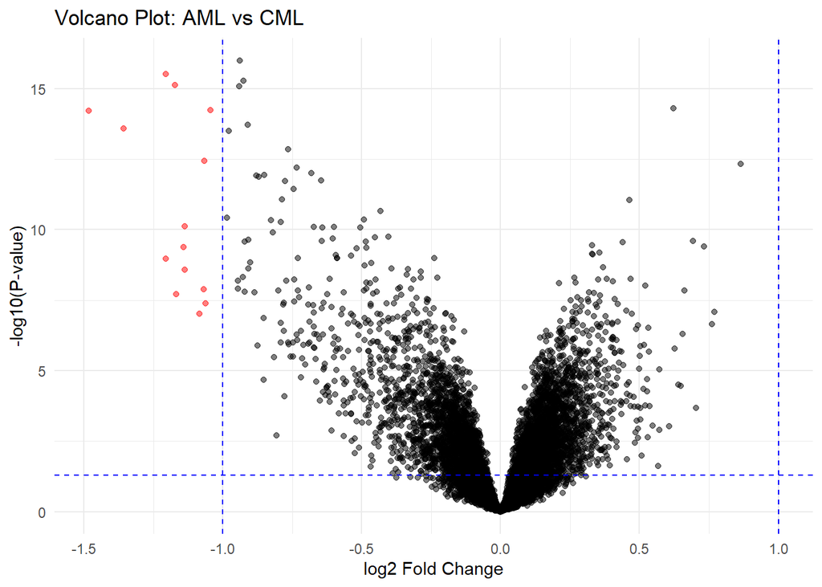

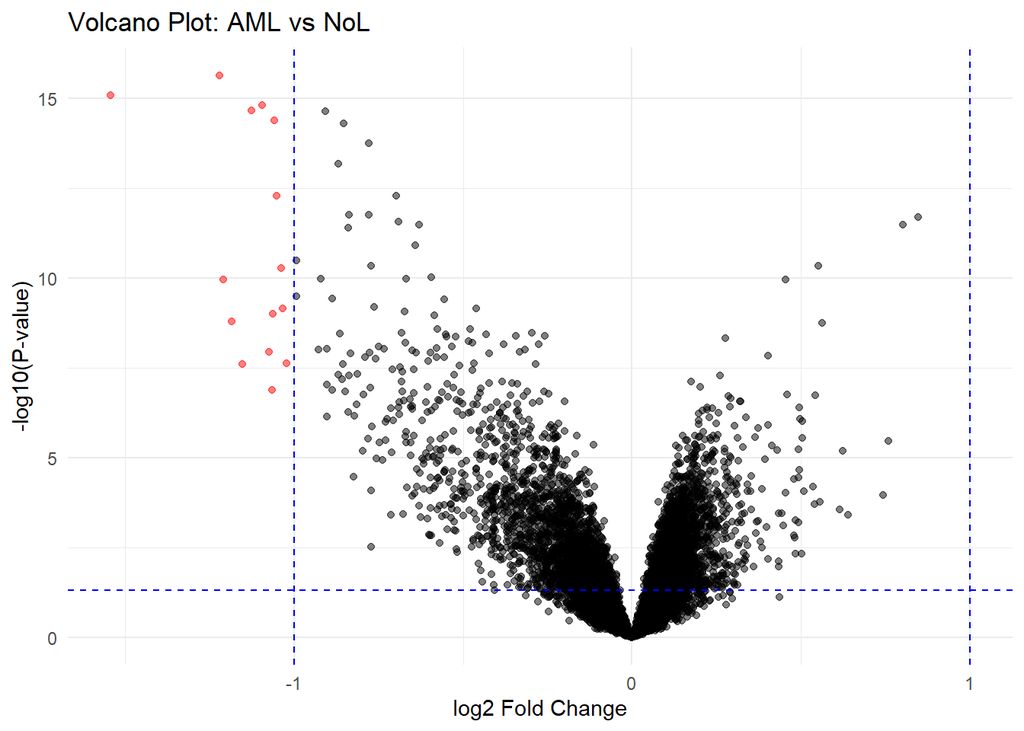

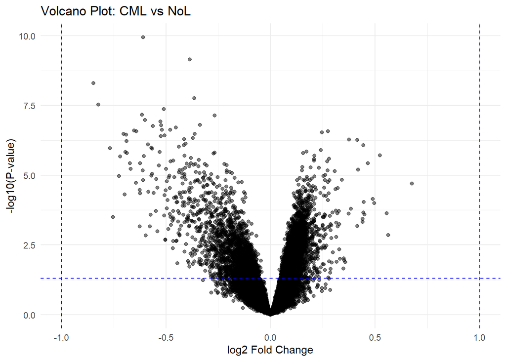

En los volcano plots AMLvsCML y AMLvsNoL se puede observar un mayor número de genes expresados diferencialmente de forma significativa (puntos rojos) en la parte izquierda del plot, esto indica que la mayoría de genes diferencialmente expresados se deben a una disminución de la expresión génica respecto al grupo con los que se les está comparando. Esto puede venir dado por la no expresión de muchos genes relacionados con la maduración de las células hematopoyéticas en pacientes con AML, debido a que en la CML o en NoL las células maduran completamente.

En el volcano plot CMLvsNoL no se observan genes diferencialmente expresados de forma significativa. Esto indica que no existen diferencias tan notables de la expresión génica entre estas dos situaciones como en las comparaciones anteriores. Esta expresion génica menos diferencial puede ser debida a que en ambos casos las células hematopoyéticas alcanzan el estado de madurez y por lo tanto las diferencias entre CML y NoL son muy sutiles. Esto encaja con que la LMC sea una forma más lenta y progresiva de leucemia en la que los pacientes puedan vivir durante varios años sin notar los efectos negativos de la enfermedad.

```
##        AMLvsCML AMLvsNoL CMLvsNoL
## Down       1642     1318      877
## NotSig     2583     3338     3721
## Up         1866     1435     1493
```

El resumen indica cuántos genes muestran diferentes niveles de expresión entre diferentes tipos de leucemia, así como entre la leucemia y muestras normales. La tabla muestra tres comparaciones principales:

- AML vs CML: Indica los genes que están sobreexpresados (Up), a la subexpresados (Down) o no muestran cambios significativos (NotSig) en su expresión entre la AML y la CML.
- AML vs NoL: Indica cuántos genes muestran diferencias en la expresión entre AML y NoL.
- CML vs NoL: Muestra los cambios en la expresión génica entre CML y las muestras NoL.

Se puede ver en la tabla que en todos los casos los genes diferencialmente expresados están sobreexpresados. Esto contradice las observaciones descritas en los VolcanoPlot. Cabe destacar que en el volcano plot daba la sensación de que hubiese un mayor número de genes diferencialmente expresados en la categoría Down porque estos puntos son más dispersos y no se solapan tanto. Los genes diferencialmente expresados Up no estan tan dispersos y por eso a simple vista puede darse el caso de que parezca que hay un menor número, cuando en realidad éste es ligeramente mayor en AMLvsCML y AMLvsNoL y muy superior en CMLvsNoL.

AMLvsCML es el grupo con un mayor número de genes diferencialmente expresados, esto indica que hay una expresión génica muy diferente entre estos dos tipos de Leucemias.

CMLvsNoL es el grupo con un menor número de genes diferencialmente expresados. Esto indica que de los dos tipos de Leucemia CML es el que presenta una expresión génica más similar a los individuos sin leucemia NoL. Una hipótesis a plantear es que como en la CML las células hematopoyéticas llegan a madurar, aunque tengan una expresión génica y un comportamiento anormal, estas se asemejan más a las muestras del grupo NoL, mientras que AML al no dejar madurar las células hematopoyéticas, presenta una expresión génica más diferenciada de NoL.

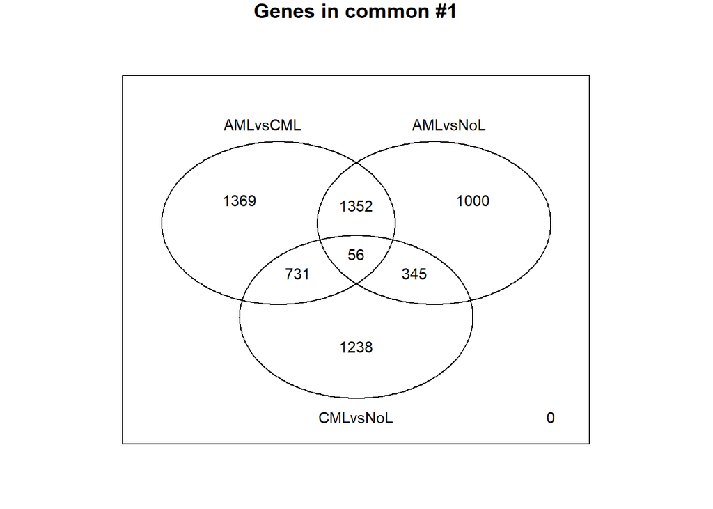

El venn diagram nos permite ver rápidamente que número de genes diferencialmente expresados comparte cada grupo y cúales son únicos y característicos de cada condición.

AMLvsCML contiene el mayor número de genes únicos diferencialmente expresados siendo así la condición que presenta más diferencias y cambios en su expresión génica. Cabe destacar también que AMLvsCML y AMLvsNoL comparten 1352 genes. Estas dos condiciones comparten un número de genes diferencialmente expresados superior a los genes compartidos en cualquiera de las otras situaciones.

### Anotacion de los genes

```r
library(org.Hs.eg.db)
library(AnnotationDbi)

keytypes(org.Hs.eg.db)
```

```
##  [1] "ACCNUM"       "ALIAS"        "ENSEMBL"      "ENSEMBLPROT"  "ENSEMBLTRANS"
##  [6] "ENTREZID"     "ENZYME"       "EVIDENCE"     "EVIDENCEALL"  "GENENAME"
## [11] "GENETYPE"     "GO"           "GOALL"        "IPI"          "MAP"
## [16] "OMIM"         "ONTOLOGY"     "ONTOLOGYALL"  "PATH"         "PFAM"
## [21] "PMID"         "PROSITE"      "REFSEQ"       "SYMBOL"       "UCSCKG"
## [26] "UNIPROT"
```

```r
# seleccionamos el identificador Symbol, juntamente con el GeneName

cols <- c("SYMBOL", "GENENAME")
annotation_AMLvsCML <- AnnotationDbi::select(org.Hs.eg.db, keys = rownames(topTabAMLvsCML), columns = cols, keytype = "ENSEMBL")
annotation_AMLvsNoL <- AnnotationDbi::select(org.Hs.eg.db, keys = rownames(topTabAMLvsNoL), columns = cols, keytype = "ENSEMBL")
annotation_CMLvsNoL <- AnnotationDbi::select(org.Hs.eg.db, keys = rownames(topTabCMLvsNoL), columns = cols, keytype = "ENSEMBL")

head(annotation_AMLvsCML)
```

```
##           ENSEMBL  SYMBOL                                     GENENAME
## 1 ENSG00000160180    TFF3                             trefoil factor 3
## 2 ENSG00000229314    ORM1                                orosomucoid 1
## 3 ENSG00000100985    MMP9                    matrix metallopeptidase 9
## 4 ENSG00000133048  CHI3L1                           chitinase 3 like 1
## 5 ENSG00000184292 TACSTD2 tumor associated calcium signal transducer 2
## 6 ENSG00000196576  PLXNB2                                    plexin B2
```

```r
head(annotation_AMLvsNoL)
```

```
##           ENSEMBL  SYMBOL                                     GENENAME
## 1 ENSG00000229314    ORM1                                orosomucoid 1
## 2 ENSG00000102837   OLFM4                               olfactomedin 4
## 3 ENSG00000133063   CHIT1                                  chitinase 1
## 4 ENSG00000133048  CHI3L1                           chitinase 3 like 1
## 5 ENSG00000184292 TACSTD2 tumor associated calcium signal transducer 2
## 6 ENSG00000164047    CAMP           cathelicidin antimicrobial peptide
```

```r
head(annotation_CMLvsNoL)
```

```
##           ENSEMBL  SYMBOL                                  GENENAME
## 1 ENSG00000109943   CRTAM  cytotoxic and regulatory T cell molecule
## 2 ENSG00000196576  PLXNB2                                 plexin B2
## 3 ENSG00000095585    BLNK                             B cell linker
## 4 ENSG00000132274  TRIM22            tripartite motif containing 22
## 5 ENSG00000110777 POU2AF1 POU class 2 homeobox associating factor 1
## 6 ENSG00000211598 IGKV4-1         immunoglobulin kappa variable 4-1
```

Anotamos con Symbol los genes para cada condición y también anotamos el GeneName para tener una descripción un poco más extensa de las posibles funcionalidades e implicaciones del gen en cuestión.

### Analisis de significación Biológica

#### Gene Set Enrichment Analysis

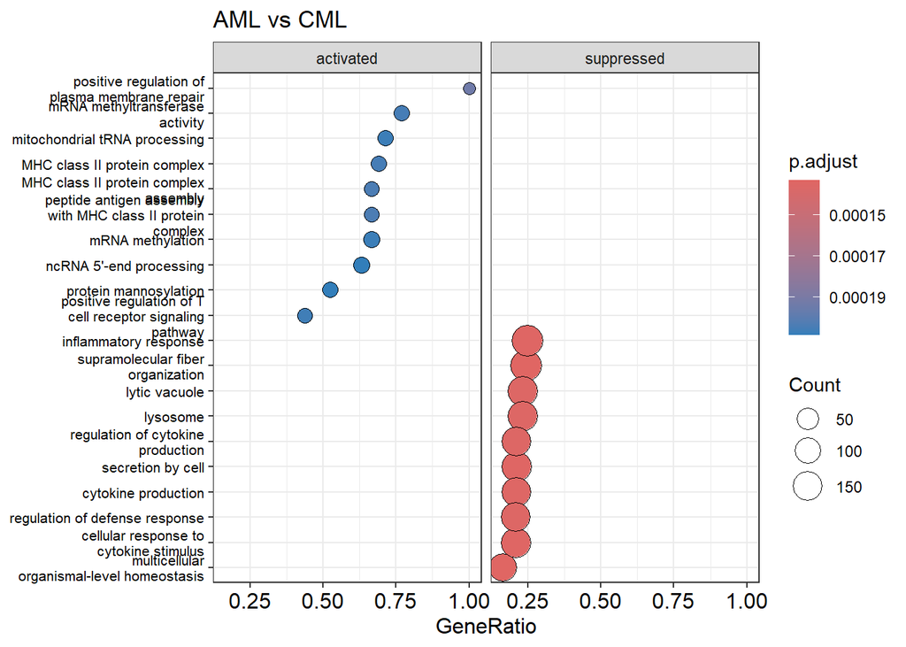

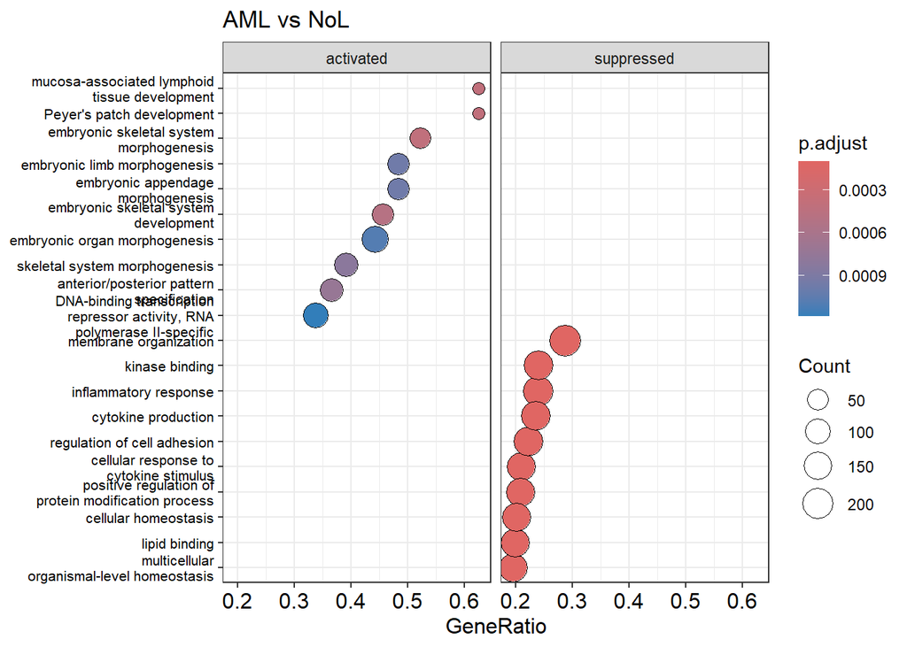

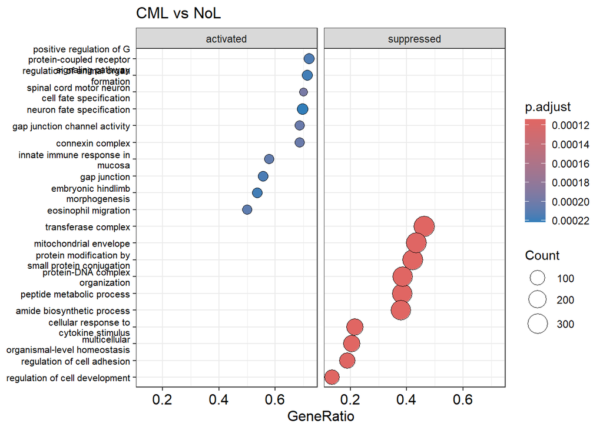

Los DotPlots para cada condición nos permiten ver que gene sets se estan expresando diferencialmente en cada una de las 3 comparaciones:

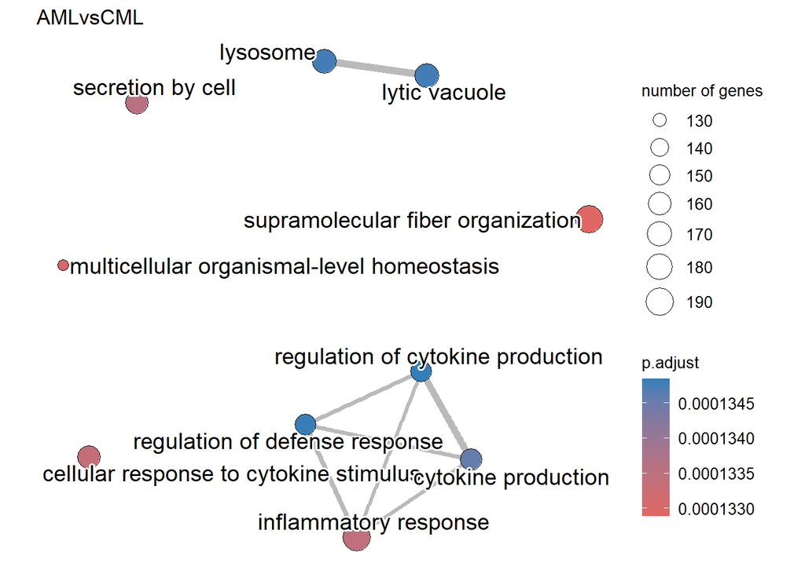

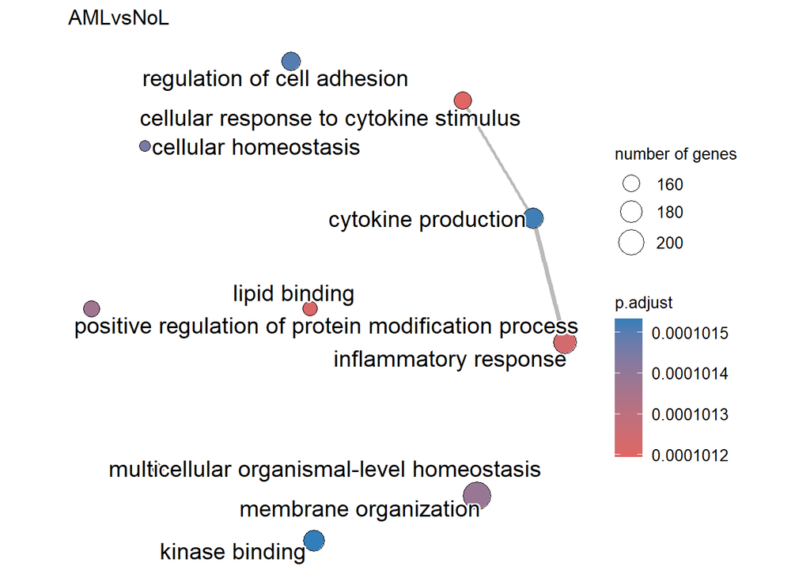

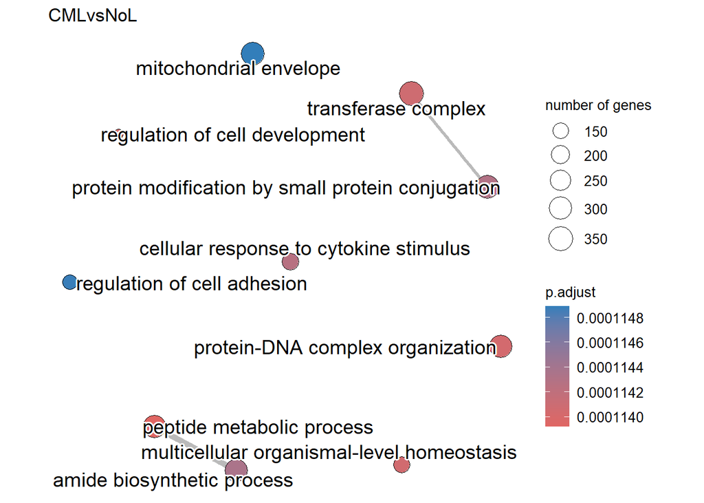

El mapa de enriquecimiento organiza los términos enriquecidos en una red con lineas que conectan conjuntos de genes superpuestos. De esta manera, los conjuntos de genes que se superponen entre sí tienden a agruparse, lo que facilita la identificación de módulos funcionales.